# Time to event models: lab

SUPPORT ICU data and NCCTG lung cancer data

Timothy Hofer

thofer@umich.edu

University of Michigan

November 10, 2026

## Plan

Each task: work for 5 to 10 minutes, then we review the answer together.

|  | Task | Work | Review |
| --- | --- | --- | --- |
| **SUPPORT** | 1. Declare the data, describe follow-up | 5 | 2 |
|  | 2. Kaplan-Meier and log-rank by disease group | 6 | 3 |
|  | 3. Cox regression with a continuous predictor | 8 | 4 |
|  | 4. Proportional hazards; stratified Cox | 8 | 4 |
|  | 5. Right heart catheterization | 8 | 4 |
|  | 6. Interaction | 7 | 4 |
|  | 7. Competing risks | 10 | 5 |
| **Lung** | 8. Cox regression for sex | 6 | 3 |
|  | 9. Proportional hazards for Karnofsky score | 7 | 3 |
|  | 10. Splitting follow-up time | 8 | 4 |

A slide of hints follows each task. Try the task before you read it. Hints and answer slides carry the question number (Q1, Q2, …).

# SUPPORT: survival after ICU admission

## The data

- 5,735 seriously ill adults who were in an ICU on study day 1 (SUPPORT study)
- Analysis time starts at study admission
- Outcome for tasks 1 to 6: death from any cause within 30 days

| Variable |  |
| --- | --- |
| `t3d30` | days from admission to death, capped at 30 |
| `dth30` | death within 30 days (1 = yes) |
| `surv2md1` | SUPPORT model prediction on day 1 of the probability of surviving 2 months (0 to 1). Combines diagnosis, age, physiology, coma score. |
| `cat1` | primary disease category (9 categories) |
| `swang1` | right heart catheterization (RHC) within 24 hours (1 = yes) |
| `sadmdte`, `dschdte`, `dthdte` | admission, discharge and death dates |

## Setup: run this first

```stata
use https://tphofer.github.io/ncsp-hhcr/data/rhc_class_tph.dta, clear

* Disease group: the three cancer categories combined
recode cat1 (1 = 1 "ARF") (9 = 2 "MOSF w/sepsis") (2 = 3 "COPD") (3 = 4 "CHF") ///
            (4 = 5 "Cirrhosis") (5 = 6 "Coma") (6 7 8 = 7 "Cancer"),          ///
            generate(disease_group)

* Predicted 2-month survival, centered at 0.6, in units of 0.1
generate surv_pred10 = (surv2md1 - 0.6) * 10

* Quartiles of predicted survival, for plots
xtile surv_quartile = surv2md1, nquantiles(4)
label define surv_quartile 1 "Q1 (lowest)" 2 "Q2" 3 "Q3" 4 "Q4 (highest)"
label values surv_quartile surv_quartile

label define rhc 0 "No RHC" 1 "RHC"
label values swang1 rhc
```

ARF = acute respiratory failure; MOSF = multiple organ system failure.

## Task 1: declare the data and describe follow-up

Commands: `stset`, `stdescribe`, `stsum`, `sts list`, `sts graph`

1. `stset` the data. How many patients, deaths and person-days at risk are there?
2. When does censoring occur? Is the assumption that censoring is unrelated to the outcome a concern here?
3. Graph the Kaplan-Meier curve for the whole cohort. What is the estimated survival at 7, 14 and 30 days?
4. `stsum` reports the 25th percentile of survival time and no median. Why?

*5 minutes*

## Task 1: hints

- **Q1.** `stset <time var>, failure(<event indicator var>)`: one record per person, everyone at risk from time 0. Same form as the first leukemia problem (chapter, Application, “Kaplan-Meier curve”).
- **Q2.** Look at who has `_d == 0` and their `_t`:

  `tabulate t3d30 dth30 if t3d30 >= 28`

  Chapter: “Right censoring” for the independence assumption.
- **Q3.** `sts graph, ci risktable` and `sts list, at(7 14 30)`
- **Q4.** The median survival time is the time at which the Kaplan-Meier curve reaches 0.5

## Task 1, Q1: `stset`

```stata
stset t3d30, failure(dth30)
```

```
Survival-time data settings

         Failure event: dth30!=0 & dth30<.
Observed time interval: (0, t3d30]
     Exit on or before: failure

--------------------------------------------------------------------------
      5,735  total observations
          0  exclusions
--------------------------------------------------------------------------
      5,735  observations remaining, representing
      1,918  failures in single-record/single-failure data
    135,416  total analysis time at risk and under observation
                                                At risk from t =         0
                                     Earliest observed entry t =         0
                                          Last observed exit t =        30
```

- 5,735 patients, 1,918 deaths (33.4%), 135,416 person-days at risk
- Earliest entry is 0 and there are no exclusions: one record per patient, no delayed entry

## Task 1, Q2: when does censoring occur?

```stata
tabulate t3d30 dth30 if t3d30 >= 28
```

```
min{dthdte | Outcome:Death within
- sadmdte, |          30d
       30} |        no        yes |     Total
-----------+----------------------+----------
        28 |         0         18 |        18
        29 |         0         23 |        23
        30 |     3,817         26 |     3,843
-----------+----------------------+----------
     Total |     3,817         67 |     3,884
```

- All 3,817 censored patients are censored at day 30, when follow-up was cut off (administrative censoring)
- A fixed cut-off does not depend on prognosis, so independence of censoring is not a concern

## Task 1, Q3 and Q4: survival and the median

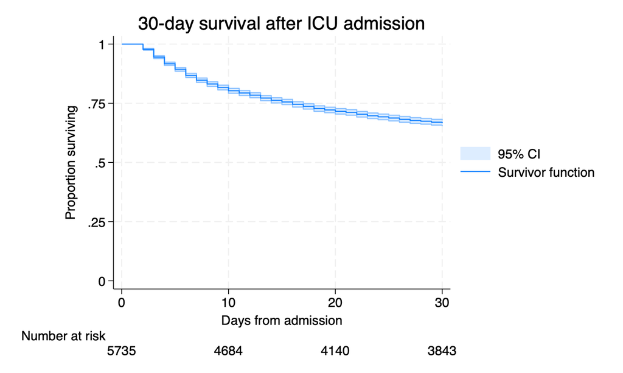

```stata
sts list, at(7 14 30)
```

```
Kaplan–Meier survivor function

              Beg.             Survivor      Std.
    Time     total     Fail    function     error     [95% conf. int.]
----------------------------------------------------------------------
       7      4977      874      0.8476    0.0047     0.8380    0.8567
      14      4428      488      0.7625    0.0056     0.7513    0.7733
      30      3843      556      0.6656    0.0062     0.6532    0.6776
----------------------------------------------------------------------
Note: Survivor function is calculated over full data and evaluated at
      indicated times; it is not calculated from aggregates shown at left.
```

- **Q3.** Survival is 0.848 at 7 days, 0.763 at 14 days and 0.666 at 30 days (95% CI 0.653 to 0.678). The curve is steepest in the first 10 days: the hazard of death is highest early and falls.
- **Q4.** The curve reaches 0.75 at day 16 and never reaches 0.50 within 30 days. The median survival time cannot be estimated; we know only that it exceeds 30 days.

## Task 2: Kaplan-Meier and log-rank by disease group

Commands: `sts graph`, `sts list`, `sts test`

1. Graph the Kaplan-Meier curves by `disease_group`. Which groups have the best and the worst 30-day survival?
2. Run the log-rank test. State its null hypothesis and what you conclude.
3. What don’t you learn from the test?
4. Do any of the curves suggest non-proportional hazards?

*6 minutes*

## Task 2: hints

- **Q1.** `sts graph, by(<group var>)` and `sts list, by(<group var>) at(10 20 30)`
- **Q2.** `sts test <group var>`. In the table, compare observed with expected deaths group by group.
- **Q3.** Morning slides: “Problem 1: what the log-rank test tells you”
- **Q4.** Look for curves that are steep early and flat later while others do the opposite. The second treatment in the leukemia data is an extreme example (chapter, Application, “A second treatment analysis”).

## Task 2, Q1: survival by disease group

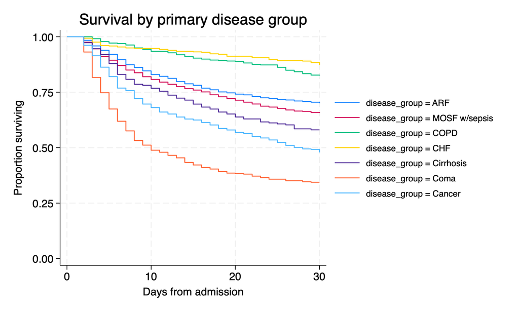

30-day survival: CHF 0.87 and COPD 0.82 are highest; coma 0.34 and cancer 0.48 are lowest.

## Task 2, Q2 and Q3: log-rank test

```stata
sts test disease_group
```

```
Equality of survivor functions
Log-rank test

              |  Observed       Expected
disease_gr~p  |    events         events
--------------+-------------------------
          ARF |       746         855.74
MOSF w/sepsis |       422         410.03
         COPD |        80         172.98
          CHF |        58         173.91
    Cirrhosis |        94          71.44
         Coma |       286         102.80
       Cancer |       232         131.10
--------------+-------------------------
        Total |      1918        1918.00

                        chi2(6) = 566.76
                        Pr>chi2 = 0.0000
```

- **Q2.** Null hypothesis: the seven groups have the same survival function over the 30 days. We reject it (chi2(6) = 566.8, p < 0.0001).
- Coma: 286 deaths observed, 102.8 expected. CHF: 58 observed, 173.9 expected.
- **Q3.** The test gives **no effect size**, does not say which groups differ from which, and does not adjust for severity of illness

## Task 2, Q4: non-proportional hazards?

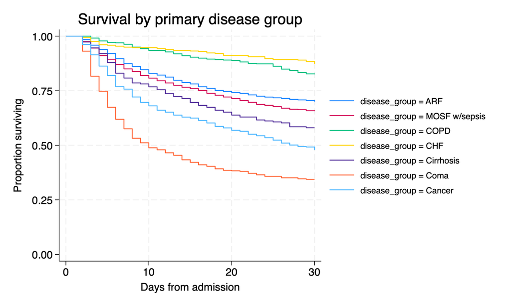

## Task 3: Cox regression with a continuous predictor

Commands: `stcox`, `stcurve`

`surv_pred10 = (surv2md1 - 0.6) * 10`

1. Fit a Cox model with `disease_group` only, then one with `surv_pred10` only. Interpret the hazard ratio for `surv_pred10`.
2. Fit a model with both. What happens to the disease-group hazard ratios, and why?
3. Which patient does the baseline hazard of the model in question 2 describe? Why did we rescale and center `surv2md1`?
4. Plot the survival predicted by that model for an ARF patient with predicted 2-month survival of 0.3, 0.6 and 0.8

*8 minutes*

## Task 3: hints

- **Q1.** `stcox i.disease_group, nolog` reports hazard ratios; ARF is the reference group. A hazard ratio is for a 1-unit difference: what is 1 unit of `surv_pred10`?
- **Q2.** `tabulate disease_group, summarize(surv2md1)`
- **Q3.** The baseline hazard is the hazard when every covariate is 0 (chapter, “The mathematical model” and the paragraph on centering in “Cox proportional hazards model”). Try `stcox surv2md1` and ask what 1 unit means.
- **Q4.** `surv2md1` = 0.3, 0.6, 0.8 is `surv_pred10` = −3, 0, 2:

  `stcurve, survival at(surv_pred10 = (-3 0 2) disease_group = 1)`

## Task 3, Q1: disease group only

```stata
stcox i.disease_group, nolog
```

```
Cox regression with Breslow method for ties

No. of subjects =   5,735                               Number of obs =  5,735
No. of failures =   1,918
Time at risk    = 135,416
                                                        LR chi2(6)    = 472.93
Log likelihood = -16017.234                             Prob > chi2   = 0.0000

--------------------------------------------------------------------------------
            _t | Haz. ratio   Std. err.      z    P>|z|     [95% conf. interval]
---------------+----------------------------------------------------------------
 disease_group |
MOSF w/sepsis  |   1.181126   .0719447     2.73   0.006     1.048209    1.330897
         COPD  |   .5293981   .0622856    -5.41   0.000     .4203737    .6666983
          CHF  |   .3815065   .0520099    -7.07   0.000     .2920516    .4983613
    Cirrhosis  |   1.512239   .1655218     3.78   0.000      1.22026    1.874081
         Coma  |   3.218255   .2244926    16.76   0.000      2.80701    3.689749
       Cancer  |   2.037107   .1532022     9.46   0.000     1.757918    2.360637
--------------------------------------------------------------------------------
```

Compared to ARF, the hazard of death is 3.2 times as high for coma and 0.38 times as high for CHF.

## Task 3, Q1: predicted survival only

```stata
stcox surv_pred10, nolog
```

```
Cox regression with Breslow method for ties

No. of subjects =   5,735                               Number of obs =  5,735
No. of failures =   1,918
Time at risk    = 135,416
                                                        LR chi2(1)    = 886.06
Log likelihood = -15810.668                             Prob > chi2   = 0.0000

------------------------------------------------------------------------------
          _t | Haz. ratio   Std. err.      z    P>|z|     [95% conf. interval]
-------------+----------------------------------------------------------------
 surv_pred10 |   .7236523    .007486   -31.27   0.000     .7091278    .7384742
------------------------------------------------------------------------------
```

Each additional 0.1 of predicted 2-month survival is associated with a 28% lower hazard of death, at every time in the first 30 days.

## Task 3, Q2: both predictors

```stata
stcox surv_pred10 i.disease_group, nolog
```

```
Cox regression with Breslow method for ties

No. of subjects =   5,735                               Number of obs =  5,735
No. of failures =   1,918
Time at risk    = 135,416
                                                        LR chi2(7)    = 953.69
Log likelihood = -15776.852                             Prob > chi2   = 0.0000

--------------------------------------------------------------------------------
            _t | Haz. ratio   Std. err.      z    P>|z|     [95% conf. interval]
---------------+----------------------------------------------------------------
   surv_pred10 |   .7505004   .0093814   -22.96   0.000     .7323366    .7691147
 disease_group |
MOSF w/sepsis  |   1.080221   .0658453     1.27   0.206     .9585779    1.217301
         COPD  |   .7040361    .083343    -2.96   0.003     .5582524    .8878902
          CHF  |   .6585817   .0915713    -3.00   0.003     .5014826    .8648952
    Cirrhosis  |   1.449893    .158707     3.39   0.001     1.169937     1.79684
         Coma  |   1.563822   .1200732     5.82   0.000     1.345335    1.817792
       Cancer  |    1.02096   .0818941     0.26   0.796     .8724317    1.194775
--------------------------------------------------------------------------------
```

## Task 3, Q2: why the disease-group hazard ratios move

```stata
tabulate disease_group, summarize(surv2md1)
```

```
    Primary |    Summary of 2M model survival
    disease |         prediction at day 1
      group |        Mean   Std. dev.       Freq.
------------+------------------------------------
        ARF |   .61642574   .16740834       2,490
  MOSF w/se |   .58296104   .15332044       1,227
       COPD |   .72352731   .14828307         457
        CHF |   .79577912   .09728661         456
  Cirrhosis |   .58619318   .15035588         224
       Coma |   .36714438   .19876017         436
     Cancer |   .36538969    .1527719         445
------------+------------------------------------
      Total |   .59245008   .19535368       5,735
```

- The disease-group hazard ratios move toward 1: coma 3.22 to 1.56, cancer 2.04 to 1.02, CHF 0.38 to 0.66
- The prognostic model already uses diagnosis, and mean predicted survival differs widely by group (coma 0.37, CHF 0.80)
- What remains is what the prediction does not capture: at the same predicted survival, coma and cirrhosis patients still die at a higher rate than ARF patients in the first 30 days

## Task 3, Q3: baseline hazard and rescaling

- The baseline hazard describes an ARF patient with predicted 2-month survival of 0.6: every covariate at 0
- On the raw scale, 1 unit of `surv2md1` is the difference between predicted survival of 0 and of 1. The hazard ratio is 0.039, a comparison of two patients who do not exist.
- Without centering, the baseline hazard would describe a patient with predicted survival of 0
- Rescaling and centering change the units and the baseline. The fit is identical.

## Task 3, Q4: predicted survival

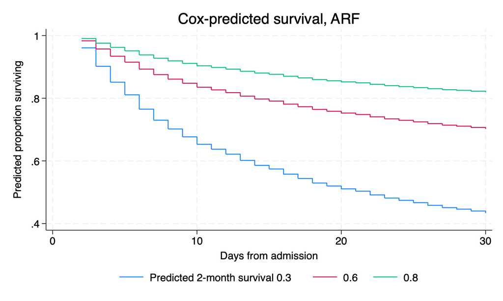

Predicted 30-day survival, ARF

| 2-month prediction | 30-day survival |
| --- | --- |
| 0.3 | 0.43 |
| 0.6 | 0.70 |
| 0.8 | 0.82 |

The curves cannot cross: each is the baseline curve raised to a fixed power. That is the proportional hazards assumption, not a finding.

## Task 4: proportional hazards and the stratified Cox model

Commands: `stcoxkm`, `stphplot`, `estat phtest`, `stcox` with `strata()`

The model `stcox surv_pred10 i.disease_group` assumes each hazard ratio is the same on every day.

1. Compare observed (Kaplan-Meier) with Cox-predicted survival by `surv_quartile`
2. Draw the log-log plot for `disease_group`, adjusted for `surv_pred10`
3. Run the Schoenfeld residual test on the model. Which covariates violate proportional hazards? With 1,918 deaths, how much weight do you give the test relative to the plots?
4. Disease group is not the predictor of interest. Refit the model stratified on `disease_group`. What is gained and at what cost?

*8 minutes*

## Task 4: hints

The three checks are in the chapter, Application, “Testing for proportional hazards”.

- **Q1.** `stcoxkm, by(<var>)` takes no other covariates
- **Q2.** `stphplot, by(<var>) adjustfor(<covariate>)`: parallel curves are what proportional hazards predicts
- **Q3.** `estat phtest, detail` after `stcox`. The null hypothesis is proportional hazards. `rho` > 0: the hazard ratio rises with time.
- **Q4.** `stcox <covariates>, strata(<var>)` gives each stratum its own baseline hazard. It is one of the responses to non-proportional hazards listed at the end of the morning slides.

## Task 4, Q1 and Q2: graphical checks

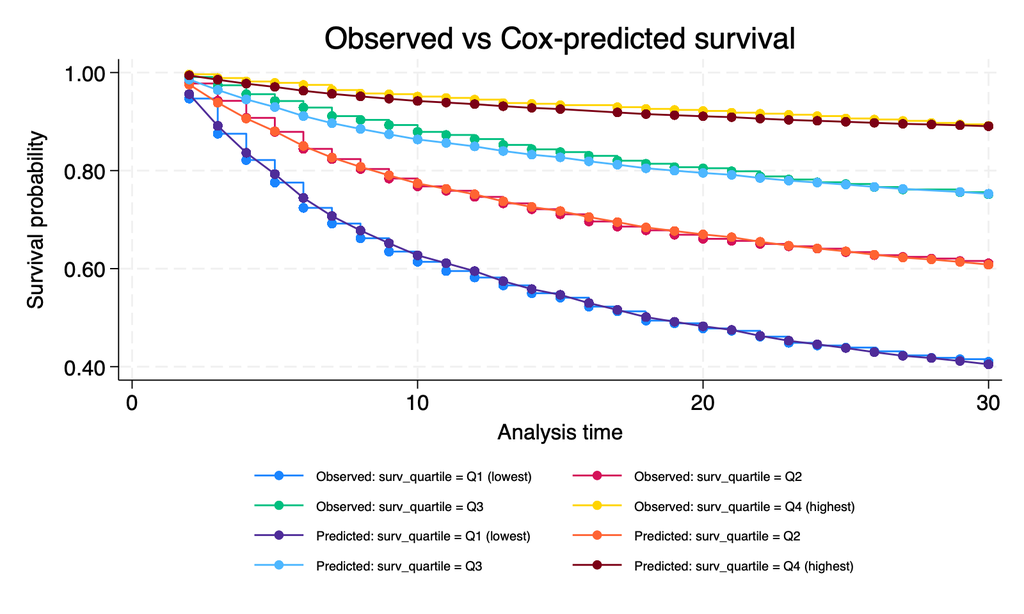

Q1: by quartile of predicted survival

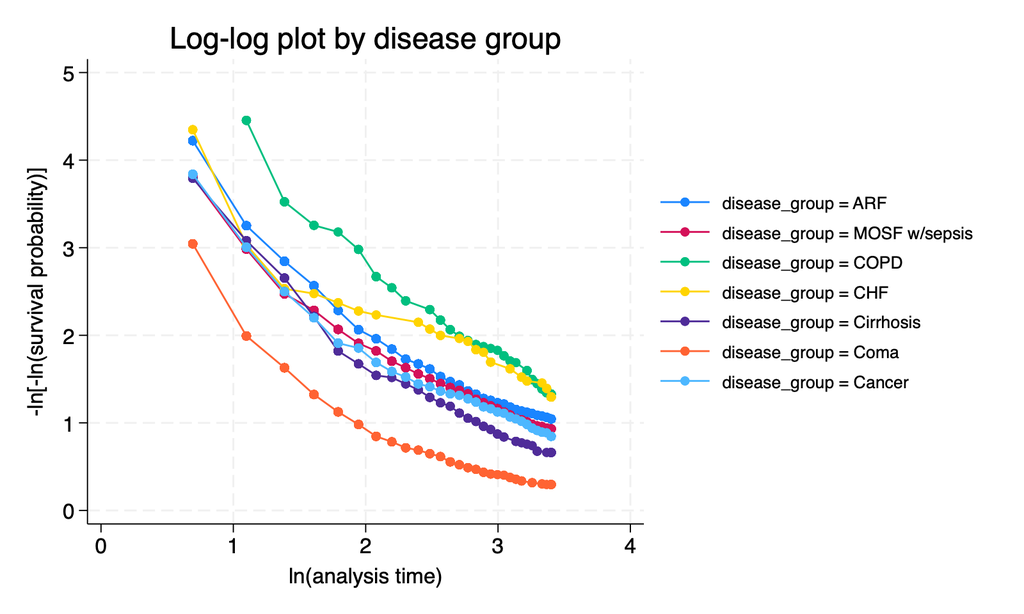

Q2: adjusted for predicted survival

- **Q1.** Predicted survival: Cox-predicted curves follow the Kaplan-Meier curves in all four quartiles
- **Q2.** Disease group: coma is separated by a gap that narrows with time. COPD starts far from the others and converges on them. Not parallel.

## Task 4, Q3: Schoenfeld residual test

```stata
estat phtest, detail
```

```
Test of proportional-hazards assumption

Time function: Analysis time
--------------------------------------------------------
             |        rho     chi2       df    Prob>chi2
-------------+------------------------------------------
 surv_pred10 |    0.01997     0.66        1       0.4176
1b.disease~p |          .        .        1           .
2.disease_~p |    0.00520     0.05        1       0.8195
3.disease_~p |    0.09479    17.15        1       0.0000
4.disease_~p |    0.04300     3.53        1       0.0604
5.disease_~p |    0.01335     0.34        1       0.5588
6.disease_~p |   -0.05743     6.66        1       0.0099
7.disease_~p |    0.02351     1.08        1       0.2994
-------------+------------------------------------------
 Global test |               40.65        7       0.0000
--------------------------------------------------------
```

- We reject proportional hazards globally. `surv_pred10` does not violate it (p = 0.42). COPD (group 3; rho = 0.09) and coma (group 6; rho = −0.06) do.
- With 1,918 deaths the test detects departures too small to matter, so judge their size from the plots. Here the plots agree with the test.
- In a small sample the problem is reversed: a non-significant test is weak evidence for proportional hazards

## Task 4, Q4: stratified model

```stata
stcox surv_pred10, strata(disease_group) nolog
```

```
Stratified Cox regression with Breslow method for ties
Strata variable: disease_group

No. of subjects =   5,735                               Number of obs =  5,735
No. of failures =   1,918
Time at risk    = 135,416
                                                        LR chi2(1)    = 474.05
Log likelihood = -12689.17                              Prob > chi2   = 0.0000

------------------------------------------------------------------------------
          _t | Haz. ratio   Std. err.      z    P>|z|     [95% conf. interval]
-------------+----------------------------------------------------------------
 surv_pred10 |   .7516163   .0094178   -22.79   0.000     .7333825    .7703035
------------------------------------------------------------------------------
```

The `surv_pred10` hazard ratio is unchanged: 0.75 (95% CI 0.73 to 0.77).

## Task 4, Q4: stratification advantages/disadvantages

```stata
estat phtest
```

```
Test of proportional-hazards assumption

Time function: Analysis time
------------------------------------------------
             |     chi2       df       Prob>chi2
-------------+----------------------------------
 Global test |     0.95        1          0.3293
------------------------------------------------
```

- Each disease group has its own baseline hazard, of any shape. One hazard ratio for `surv_pred10` is estimated from comparisons within groups.
- Gain: no proportional hazards assumption for disease group
- Cost: no hazard ratios for disease group

## Task 5: right heart catheterization

Commands: `sts graph`, `sts test`, `tabulate`, `stcox`, `estat phtest`

RHC (`swang1`) was not randomized: physicians chose who received it. Connors et al. (JAMA 1996) used these data to ask whether RHC was associated with mortality.

1. Graph the Kaplan-Meier curves by RHC and run the log-rank test
2. Look for evidence that predicted survival and disease group confound the comparison
3. Fit three Cox models for RHC: unadjusted; adjusted for `surv_pred10`; adjusted for `surv_pred10` and stratified on `disease_group`. Interpret the RHC hazard ratios.
4. Check proportional hazards for RHC
5. Can you conclude that RHC raises the hazard of death?

*8 minutes*

## Task 5: hints

This is similar to the second leukemia problem but with a new exposure (chapter, Application, “Cox proportional hazard regression”).

- **Q1.** `sts graph, by(swang1) risktable` and `sts test swang1`
- **Q2.** A confounder is associated with the exposure and with the outcome. Tasks 2 and 3 showed the association with death. For the association with RHC:

  `tabulate disease_group swang1, row`

  `tabulate swang1, summarize(surv2md1)`
- **Q3.** `stcox i.swang1 surv_pred10, strata(disease_group)`
- **Q4.** `estat phtest, detail` and `stphplot, by(swang1) adjustfor(surv_pred10)`
- **Q5.** Ask what determined who received RHC and whether two covariates capture it

## Task 5, Q1: unadjusted comparison

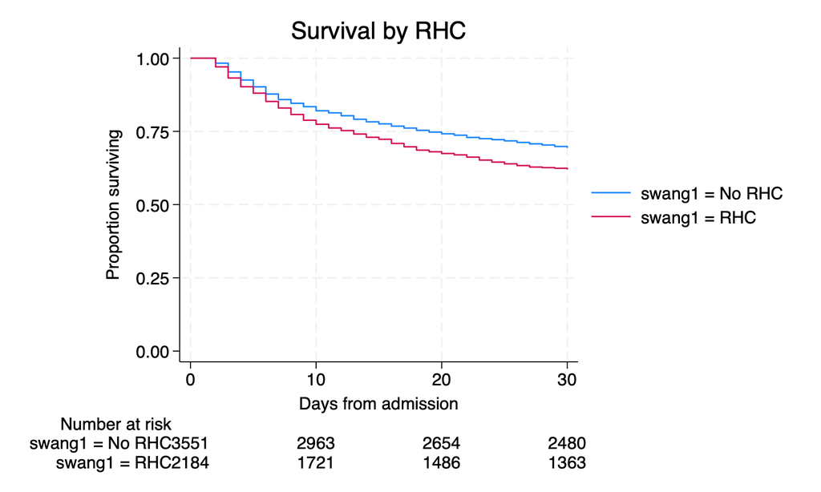

```stata
sts test swang1
```

```
Equality of survivor functions
Log-rank test

       |  Observed       Expected
swang1 |    events         events
-------+-------------------------
No RHC |      1088        1209.88
   RHC |       830         708.12
-------+-------------------------
 Total |      1918        1918.00

                 chi2(1) =  33.92
                 Pr>chi2 = 0.0000
```

30-day survival is 0.62 with RHC and 0.69 without.

## Task 5, Q2: evidence of confounding

```stata
tabulate disease_group swang1, row nokey
```

```
      Primary |  RHC within 24 hours
disease group |    No RHC        RHC |     Total
--------------+----------------------+----------
          ARF |     1,581        909 |     2,490
              |     63.49      36.51 |    100.00
--------------+----------------------+----------
MOSF w/sepsis |       527        700 |     1,227
              |     42.95      57.05 |    100.00
--------------+----------------------+----------
         COPD |       399         58 |       457
              |     87.31      12.69 |    100.00
--------------+----------------------+----------
          CHF |       247        209 |       456
              |     54.17      45.83 |    100.00
--------------+----------------------+----------
    Cirrhosis |       175         49 |       224
              |     78.12      21.88 |    100.00
--------------+----------------------+----------
         Coma |       341         95 |       436
              |     78.21      21.79 |    100.00
--------------+----------------------+----------
       Cancer |       281        164 |       445
              |     63.15      36.85 |    100.00
--------------+----------------------+----------
        Total |     3,551      2,184 |     5,735
              |     61.92      38.08 |    100.00
```

```stata
tabulate swang1, summarize(surv2md1)
```

```
            |    Summary of 2M model survival
 RHC within |         prediction at day 1
   24 hours |        Mean   Std. dev.       Freq.
------------+------------------------------------
     No RHC |   .60720636   .19205382       3,551
        RHC |    .5684576   .19831631       2,184
------------+------------------------------------
      Total |   .59245008   .19535368       5,735
```

- RHC was used in 57% of MOSF with sepsis and 13% of COPD patients
- RHC patients had a worse prognosis on day 1 (0.57 compared to 0.61)
- Both covariates were measured before or at the RHC decision: candidate confounders, not consequences of RHC

## Task 5, Q3: the fully adjusted model

```stata
stcox i.swang1 surv_pred10, strata(disease_group) nolog
```

```
Stratified Cox regression with Breslow method for ties
Strata variable: disease_group

No. of subjects =   5,735                               Number of obs =  5,735
No. of failures =   1,918
Time at risk    = 135,416
                                                        LR chi2(2)    = 485.45
Log likelihood = -12683.466                             Prob > chi2   = 0.0000

------------------------------------------------------------------------------
          _t | Haz. ratio   Std. err.      z    P>|z|     [95% conf. interval]
-------------+----------------------------------------------------------------
      swang1 |
        RHC  |   1.177346   .0567209     3.39   0.001     1.071262    1.293934
 surv_pred10 |   .7569708   .0096335   -21.88   0.000     .7383229    .7760897
------------------------------------------------------------------------------
```

## Task 5, Q3: three models

| Model | RHC compared to no RHC: hazard ratio (95% CI) |
| --- | --- |
| Unadjusted | 1.30 (1.19 to 1.43) |
| Adjusted for predicted survival | 1.13 (1.03 to 1.24) |
| Adjusted for predicted survival, stratified on disease group | 1.18 (1.07 to 1.29) |

- About half of the unadjusted excess hazard is explained by the worse prognosis of RHC patients
- At the same predicted survival and in the same disease group, the hazard of death is 18% higher with RHC

## Task 5, Q4: proportional hazards for RHC

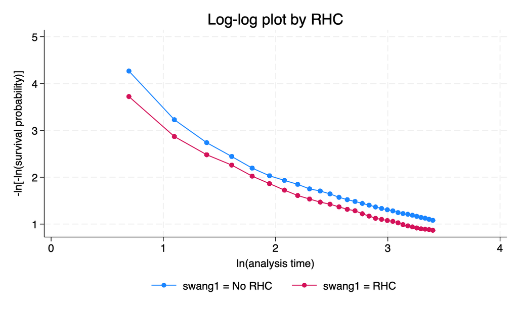

Adjusted for predicted survival

```stata
estat phtest, detail
```

```
Test of proportional-hazards assumption

Time function: Analysis time
--------------------------------------------------------
             |        rho     chi2       df    Prob>chi2
-------------+------------------------------------------
   0b.swang1 |          .        .        1           .
    1.swang1 |   -0.00184     0.01        1       0.9359
 surv_pred10 |    0.02255     0.87        1       0.3521
-------------+------------------------------------------
 Global test |                0.92        2       0.6302
--------------------------------------------------------
```

The log-log curves are parallel after day 2 and the test does not reject proportional hazards for RHC (p = 0.94). Neither check suggests a problem.

## Task 5, Q5: does RHC raise the hazard of death?

We cannot conclude that.

- The data are observational, and two covariates cannot capture everything that led physicians to choose RHC
- Residual confounding by indication is likely: patients selected for RHC may have been sicker in ways the day-1 prediction does not measure
- Connors et al. matched on a propensity score built from many more covariates and reported an odds ratio for 30-day death of 1.24 (95% CI 1.03 to 1.49), similar in direction and size
- What the data support: no sign of a survival benefit from RHC

## Task 6: interaction

Commands: `stcox` with `##`, `testparm`, `lincom`

The models in task 5 assume one RHC hazard ratio for all patients.

1. Add an interaction between RHC and `disease_group` to the model adjusted for `surv_pred10`. Test the interaction terms jointly.
2. Add an interaction between RHC and `surv_pred10` to the model stratified on `disease_group`. Interpret the three hazard ratios.
3. Estimate the RHC hazard ratio for patients with predicted 2-month survival of 0.3, 0.6 and 0.8
4. The interaction is on the hazard-ratio scale. What would you need to describe the difference in absolute 30-day risk?

*7 minutes*

## Task 6: hints

- **Q1.** `stcox i.swang1##i.disease_group surv_pred10` then `testparm i.swang1#i.disease_group`
- **Q2.** `stcox i.swang1##c.surv_pred10, strata(disease_group)`
- **Q3.** The model is linear on the log hazard scale, so the RHC log hazard ratio at `surv_pred10` = v is

  `_b[1.swang1] + v * _b[1.swang1#c.surv_pred10]`

  `lincom 1.swang1 + 2*1.swang1#c.surv_pred10, hr` gives the hazard ratio at predicted survival 0.8
- **Q4.** `sts list, by(surv_quartile swang1) at(15 30)`. Morning slides: “A caveat that applies to every hazard ratio”.

## Task 6, Q1: RHC by disease group

```stata
testparm i.swang1#i.disease_group
```

```
 ( 1)  1.swang1#2.disease_group = 0
 ( 2)  1.swang1#3.disease_group = 0
 ( 3)  1.swang1#4.disease_group = 0
 ( 4)  1.swang1#5.disease_group = 0
 ( 5)  1.swang1#6.disease_group = 0
 ( 6)  1.swang1#7.disease_group = 0

           chi2(  6) =    7.45
         Prob > chi2 =    0.2811
```

- The six interaction terms range from 0.77 (coma) to 1.28 (CHF), each with a wide confidence interval
- No good evidence that the RHC hazard ratio differs by disease group (p = 0.28)
- The test has low power in the small groups, so this does not show that the hazard ratios are equal

## Task 6, Q2: RHC by predicted survival

```stata
stcox i.swang1##c.surv_pred10, strata(disease_group) nolog
```

```
Stratified Cox regression with Breslow method for ties
Strata variable: disease_group

No. of subjects =   5,735                               Number of obs =  5,735
No. of failures =   1,918
Time at risk    = 135,416
                                                        LR chi2(3)    = 499.51
Log likelihood = -12676.438                             Prob > chi2   = 0.0000

--------------------------------------------------------------------------------------
                  _t | Haz. ratio   Std. err.      z    P>|z|     [95% conf. interval]
---------------------+----------------------------------------------------------------
              swang1 |
                RHC  |    1.29653   .0702797     4.79   0.000     1.165849    1.441859
         surv_pred10 |   .7302875   .0115559   -19.86   0.000     .7079859    .7532916
swang1#c.surv_pred10 |
                RHC  |   1.082691   .0229953     3.74   0.000     1.038547    1.128713
--------------------------------------------------------------------------------------
```

- `swang1` 1.30: the RHC hazard ratio when `surv_pred10` = 0 (predicted survival 0.6)
- `surv_pred10` 0.73: the hazard ratio per 0.1 of predicted survival among patients without RHC
- Interaction 1.08: the RHC hazard ratio is multiplied by 1.08 for each additional 0.1 of predicted survival

## Task 6, Q3: RHC hazard ratio by prognosis

```stata
lincom 1.swang1 + 2*1.swang1#c.surv_pred10, hr
```

```
 ( 1)  1.swang1 + 2*1.swang1#c.surv_pred10 = 0

------------------------------------------------------------------------------
          _t | Haz. ratio   Std. err.      z    P>|z|     [95% conf. interval]
-------------+----------------------------------------------------------------
         (1) |   1.519819   .1261217     5.04   0.000     1.291681    1.788251
------------------------------------------------------------------------------
```

| Predicted 2-month survival | RHC compared to no RHC: hazard ratio (95% CI) |
| --- | --- |
| 0.3 | 1.02 (0.91 to 1.15) |
| 0.6 | 1.30 (1.17 to 1.44) |
| 0.8 | 1.52 (1.29 to 1.79) |

RHC is not associated with the hazard of death in patients with a poor prognosis. The single hazard ratio of 1.18 in task 5 averaged over these.

## Task 6, Q4: absolute risk

| Quartile of predicted survival | 30-day survival, no RHC | RHC | Difference |
| --- | --- | --- | --- |
| Q1 (lowest) | 0.412 | 0.407 | 0.004 |
| Q2 | 0.628 | 0.587 | 0.041 |
| Q3 | 0.781 | 0.703 | 0.078 |
| Q4 (highest) | 0.901 | 0.867 | 0.034 |

- Absolute risk depends on the baseline hazard as well as on the hazard ratio
- The hazard ratio is largest in the highest quartile; the risk difference is largest in the third

## Task 7: competing risks, setup

A hospital asks how soon ICU patients are discharged alive, and whether patients who had RHC are discharged earlier. A patient who dies in hospital can never be discharged alive. Follow-up is limited to 30 days.

```stata
generate hosp_days = dschdte - sadmdte
generate byte died_in_hosp = death == 1 & dthdte <= dschdte
generate days_in_hosp = min(hosp_days, 30) if !missing(hosp_days)
generate byte hosp_event = cond(hosp_days > 30, 0, cond(died_in_hosp, 2, 1)) ///
    if !missing(hosp_days)
label define hosp_event 0 "In hospital at day 30" 1 "Discharged alive" ///
    2 "Died in hospital"
label values hosp_event hosp_event
```

`days_in_hosp`: days to discharge or death in hospital, capped at 30

`hosp_event`: 0 = still in hospital at day 30, 1 = discharged alive, 2 = died in hospital

## Task 7: competing risks

Commands: `stset`, `sts list`, `stcox`, `stcrreg`

1. Tabulate `hosp_event` by RHC. No one is censored before day 30, so the column percentages are the cumulative incidence (CIF) of each event at day 30.
2. Estimate the probability of discharge alive by day 30 as 1 − KM, with deaths in hospital censored. Compare it with the CIF. Which answers the original question?
3. Do the same for death in hospital. Add the two probabilities at day 30 for each method.
4. Fit a cause-specific Cox model for discharge alive and one for death in hospital, each with RHC and `surv_pred10`. Then fit a Fine-Gray model for discharge alive. Compare the estimates for RHC and for `surv_pred10`.

*10 minutes*

## Task 7: hints

- **Q1.** `tabulate hosp_event swang1, column`
- **Q2.** `stset days_in_hosp, failure(hosp_event == 1)` then

  `sts list, by(swang1) at(10 20 30)`

  and subtract the survivor function from 1. Morning slides: “Three estimands”.
- **Q3.** Repeat with `failure(hosp_event == 2)`
- **Q4.** Cause-specific: the same two `stset` commands, each followed by `stcox i.swang1 surv_pred10`. Fine-Gray: `stset` for discharge, then

  `stcrreg i.swang1 surv_pred10, compete(hosp_event == 2)`

  Morning slides: “Two regressions, two questions”.
- When you finish, restore the first setup: `stset t3d30, failure(dth30)`

## Task 7, Q1: what happened by day 30

```stata
tabulate hosp_event swang1, column nokey
```

```
     Hospital outcome |  RHC within 24 hours
       within 30 days |    No RHC        RHC |     Total
----------------------+----------------------+----------
In hospital at day 30 |       584        562 |     1,146
                      |     16.45      25.74 |     19.99
----------------------+----------------------+----------
     Discharged alive |     2,011        841 |     2,852
                      |     56.63      38.52 |     49.74
----------------------+----------------------+----------
     Died in hospital |       956        780 |     1,736
                      |     26.92      35.73 |     30.28
----------------------+----------------------+----------
                Total |     3,551      2,183 |     5,734
                      |    100.00     100.00 |    100.00
```

One patient has no discharge date and is excluded.

## Task 7, Q2: discharge alive, 1 − KM compared to CIF

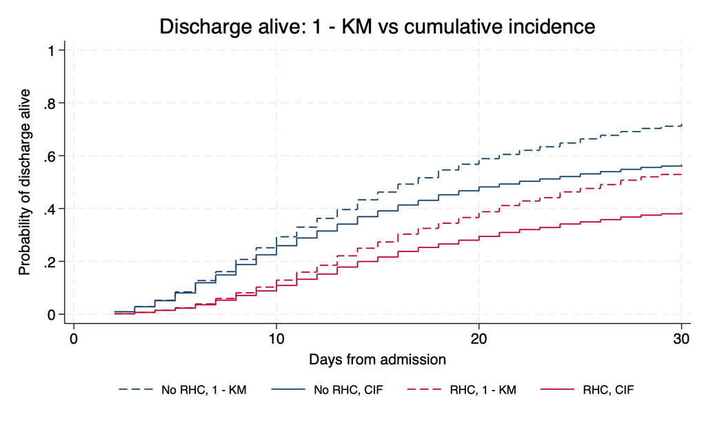

Discharge alive by day 30

|  | 1 − KM | CIF |
| --- | --- | --- |
| No RHC | 0.721 | 0.566 |
| RHC | 0.538 | 0.385 |

- 1 − KM treats patients who died as if those still in hospital could represent them. It estimates discharge in a world where no one dies in hospital.
- The CIF is the proportion of admitted patients discharged alive by each day: the hospital’s question

## Task 7, Q3: death in hospital, and the sum

Probability by day 30

|  | 1 − KM | CIF |
| --- | --- | --- |
| **Death in hospital** |  |  |
| No RHC | 0.397 | 0.269 |
| RHC | 0.435 | 0.357 |
| **Discharge alive + death in hospital** |  |  |
| No RHC | 1.118 | 0.836 |
| RHC | 0.973 | 0.742 |

- 1 − KM sums to more than 1 without RHC
- The CIFs plus the proportion still in hospital sum to 1

## Task 7, Q4: Fine-Gray model

```stata
stcrreg i.swang1 surv_pred10, compete(hosp_event == 2) nolog
```

```
        Failure _d: hosp_event==1
  Analysis time _t: days_in_hosp

Competing-risks regression                        No. of obs      =      5,734
                                                  No. of subjects =      5,734
Failure event:   hosp_event == 1                  No. failed      =      2,852
Competing event: hosp_event == 2                  No. competing   =      1,736
                                                  No. censored    =      1,146

                                                  Wald chi2(2)    =     850.20
Log pseudolikelihood = -23302.782                 Prob > chi2     =     0.0000

------------------------------------------------------------------------------
             |               Robust
          _t |        SHR   std. err.      z    P>|z|     [95% conf. interval]
-------------+----------------------------------------------------------------
      swang1 |
        RHC  |   .5933748   .0236745   -13.08   0.000     .5487415    .6416385
 surv_pred10 |   1.400121   .0182452    25.83   0.000     1.364814    1.436341
------------------------------------------------------------------------------
```

## Task 7, Q4: comparing the regressions

| Hazard ratio (95% CI) | RHC compared to no RHC | Predicted survival, per 0.1 |
| --- | --- | --- |
| Cause-specific, discharge alive | 0.59 (0.55 to 0.64) | 1.27 (1.23 to 1.30) |
| Cause-specific, death in hospital | 1.06 (0.97 to 1.17) | 0.75 (0.73 to 0.76) |
| Subdistribution (Fine-Gray), discharge alive | 0.59 (0.55 to 0.64) | 1.40 (1.36 to 1.44) |

- Cause-specific: among patients still in hospital on a given day, those with RHC are discharged alive at 0.59 times the rate of those without, and die at about the same rate
- Subdistribution: the cumulative incidence of discharge alive is lower with RHC. The two agree for RHC because RHC is only weakly associated with the competing event.
- They differ for predicted survival. A better prognosis raises the discharge rate (1.27) and lowers the death rate (0.75), which leaves more patients to be discharged. Both add to the cumulative incidence (1.40).
- The subdistribution hazard ratio is not a ratio of rates among patients at risk
- Confounding by indication applies here as in task 5

# Lung cancer dataset

## Data and setup

228 patients with advanced lung cancer (NCCTG), followed from enrollment to death or the end of observation. Described at https://tphofer.github.io/ncsp-hhcr/posts/lung/.

```stata
use https://tphofer.github.io/ncsp-hhcr/data/lung.dta, clear
stset time, failure(stata_status == 1)

* ECOG performance score: combine levels 2 and 3 (one patient has 3)
generate byte ecog3 = ph_ecog
replace ecog3 = 2 if ph_ecog == 3
label define ecog3_lbl 0 "0 Asymptomatic" 1 "1 Ambulatory" 2 "2-3 In bed"
label values ecog3 ecog3_lbl

* Age per 10 years, centered at 60
generate age10 = (age - 60) / 10

* Physician-rated Karnofsky score below 80
generate byte karno_low = ph_karno < 80 if !missing(ph_karno)
label define karno_low_lbl 0 "Score 80-100" 1 "Score 50-70"
label values karno_low karno_low_lbl
```

`time`: days; `stata_status`: 1 = died; `sex`: 1 = male, 2 = female; `ph_ecog`: 0 (asymptomatic) to 4 (bedbound); `ph_karno`: 100 = normal function, lower = more disabled

## Survival by sex

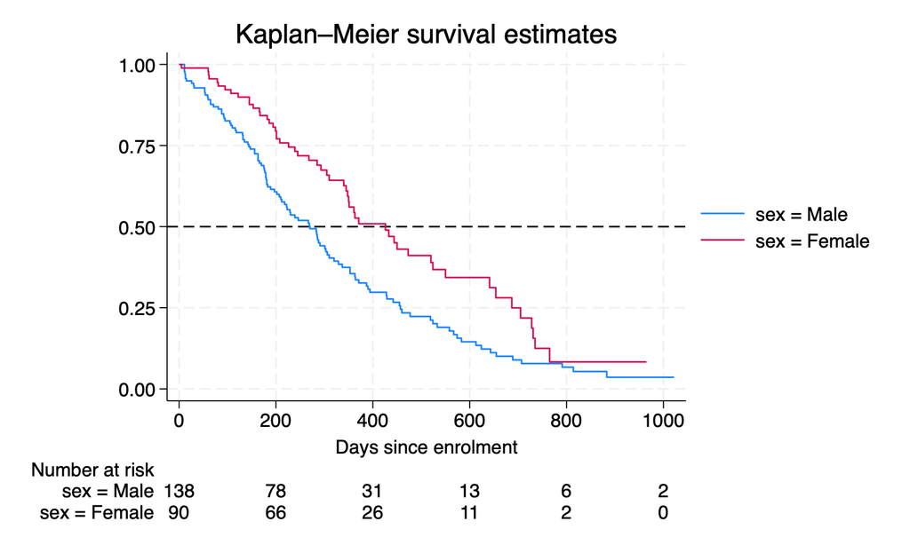

```stata
sts test sex
```

```
Equality of survivor functions
Log-rank test

       |  Observed       Expected
sex    |    events         events
-------+-------------------------
  Male |       112          91.58
Female |        53          73.42
-------+-------------------------
 Total |       165         165.00

                 chi2(1) =  10.33
                 Pr>chi2 = 0.0013
```

165 deaths; 63 patients (28%) censored. Median survival is 270 days for men and 426 days for women.

Unlike the SUPPORT data, censoring occurs throughout follow-up and the median can be estimated.

## Task 8: Cox regression for sex

Commands: `tabulate`, `ttest`, `stcox`, `testparm`

Sex was not randomized. Age and ECOG performance status predict survival and could differ by sex. One patient has a missing ECOG score.

1. Is there evidence that age or ECOG status differs by sex?
2. Fit a Cox model for sex alone, then add age and `ecog3`. Fit both models on the same patients.
3. Interpret the adjusted hazard ratio for sex in one sentence
4. Did adjustment change the hazard ratio for sex? Why or why not?

*6 minutes*

## Task 8: hints

- **Q1.** `tabulate ecog3 sex, column chi2` and `ttest age, by(sex)`
- **Q2.** `stcox` drops any patient with a missing covariate, so the two models would be fitted to different samples. Restrict both:

  `stcox i.sex if !missing(ecog3)`

  `stcox i.sex age i.ecog3`
- **Q3.** A hazard ratio is a ratio of rates among those still at risk, not a ratio of probabilities
- **Q4.** In the leukemia example, adjusting for white cell count moved the hazard ratio from 0.2 to 0.28 (chapter, Application, “Cox proportional hazard regression”). What made white cell count a confounder there?

## Task 8, Q1: are age and ECOG status balanced by sex?

```stata
tabulate ecog3 sex, column chi2 nokey
```

```
          ECOG |
   performance |
      score, 3 |          Sex
        levels |      Male     Female |     Total
---------------+----------------------+----------
0 Asymptomatic |        36         27 |        63
               |     26.28      30.00 |     27.75
---------------+----------------------+----------
  1 Ambulatory |        71         42 |       113
               |     51.82      46.67 |     49.78
---------------+----------------------+----------
    2-3 In bed |        30         21 |        51
               |     21.90      23.33 |     22.47
---------------+----------------------+----------
         Total |       137         90 |       227
               |    100.00     100.00 |    100.00

          Pearson chi2(2) =   0.6114   Pr = 0.737
```

```stata
tabstat age if complete_ecog, by(sex) statistics(n mean sd)
```

```
Summary for variables: age
Group variable: sex (Sex)

   sex |         N      Mean        SD
-------+------------------------------
  Male |       137  63.36496   9.16826
Female |        90  61.07778  8.847304
-------+------------------------------
 Total |       227  62.45815  9.092045
--------------------------------------
```

- ECOG status is similar in men and women (p = 0.74)
- Men are 2.3 years older on average (p = 0.064)

## Task 8, Q2: unadjusted model

```stata
stcox i.sex if complete_ecog, nolog
```

```
Cox regression with Breslow method for ties

No. of subjects =    227                                Number of obs =    227
No. of failures =    164
Time at risk    = 69,522
                                                        LR chi2(1)    =  10.27
Log likelihood = -739.55614                             Prob > chi2   = 0.0013

------------------------------------------------------------------------------
          _t | Haz. ratio   Std. err.      z    P>|z|     [95% conf. interval]
-------------+----------------------------------------------------------------
         sex |
     Female  |   .5927055   .0992307    -3.12   0.002     .4269047    .8228998
------------------------------------------------------------------------------
```

Women compared to men: hazard ratio 0.59 (95% CI 0.43 to 0.82).

## Task 8, Q2: adjusted model

```stata
stcox i.sex age i.ecog3 if complete_ecog, nolog
```

```
Cox regression with Breslow method for ties

No. of subjects =    227                                Number of obs =    227
No. of failures =    164
Time at risk    = 69,522
                                                        LR chi2(4)    =  29.99
Log likelihood = -729.6977                              Prob > chi2   = 0.0000

-------------------------------------------------------------------------------
           _t | Haz. ratio   Std. err.      z    P>|z|     [95% conf. interval]
--------------+----------------------------------------------------------------
          sex |
      Female  |   .5765984   .0968627    -3.28   0.001     .4148395    .8014321
          age |   1.011068   .0093997     1.18   0.236     .9928116     1.02966
        ecog3 |
1 Ambulatory  |   1.505479   .3004889     2.05   0.040     1.018069    2.226239
  2-3 In bed  |   2.494684   .5664204     4.03   0.000     1.598635    3.892975
-------------------------------------------------------------------------------
```

Women compared to men: hazard ratio 0.58 (95% CI 0.41 to 0.80).

## Task 8, Q3 and Q4: interpretation

- **Q3.** At any time during follow-up, the death rate among women still alive is an estimated 0.58 times the rate among men of the same age and ECOG status
- That is a ratio of rates. At one year the Kaplan-Meier probabilities of death are 0.47 for women and 0.66 for men, a ratio of 0.71.
- **Q4.** Adjustment did not change the hazard ratio (0.59 unadjusted, 0.58 adjusted)
- A confounder must be associated with the exposure and with the outcome. ECOG status predicts death strongly (ECOG 2-3 compared to 0: hazard ratio 2.49) but is balanced by sex. Age differs slightly by sex but is a weak predictor here.
- The model adjusts only for what was measured: smoking history, histology and stage are not in the data

## Task 9: proportional hazards for Karnofsky score

Commands: `stcox`, `stcoxkm`, `stphplot`, `estat phtest`

The Karnofsky score is the physician’s rating of function at enrolment. A rating made on day 0 may predict death in the next few months better than death two years later.

1. Fit a Cox model with `karno_low`, `age10` and sex
2. Check proportional hazards for `karno_low` three ways. What does each show?
3. Run the Schoenfeld test on the adjusted sex model from task 8. Can you conclude that the hazards for men and women are proportional?
4. Given your answer to question 2, what does the hazard ratio for `karno_low` measure?

*7 minutes*

## Task 9: hints

- **Q1.** `stcox i.karno_low age10 i.sex`
- **Q2.** The three checks, as in task 4 and the chapter, Application, “Testing for proportional hazards”:

  `stcoxkm, by(karno_low)`

  `stphplot, strata(karno_low) adjustfor(age10 i.sex)`

  `estat phtest, detail` (run it straight after the `stcox` you want to test)

  In `stcoxkm`, ask where the observed curve is below the predicted curve and where it is above.
- **Q3.** Refit `stcox i.sex age i.ecog3`, then `estat phtest, detail`. Compare the number of deaths here (164) with the SUPPORT data (1,918).
- **Q4.** Recall the Women’s Health Initiative example on the morning slides

## Task 9, Q1: the model

```stata
stcox i.karno_low age10 i.sex, nolog
```

```
Cox regression with Breslow method for ties

No. of subjects =    227                                Number of obs =    227
No. of failures =    164
Time at risk    = 69,488
                                                        LR chi2(3)    =  18.38
Log likelihood = -735.50917                             Prob > chi2   = 0.0004

------------------------------------------------------------------------------
          _t | Haz. ratio   Std. err.      z    P>|z|     [95% conf. interval]
-------------+----------------------------------------------------------------
   karno_low |
Score 50-70  |   1.464616   .2547866     2.19   0.028     1.041472    2.059681
       age10 |   1.143537   .1074125     1.43   0.153     .9512552    1.374687
         sex |
     Female  |   .6048208    .101259    -3.00   0.003     .4356309    .8397205
------------------------------------------------------------------------------
```

Low score compared to a score of 80 or more: hazard ratio 1.46 (95% CI 1.04 to 2.06).

## Task 9, Q2: graphical checks

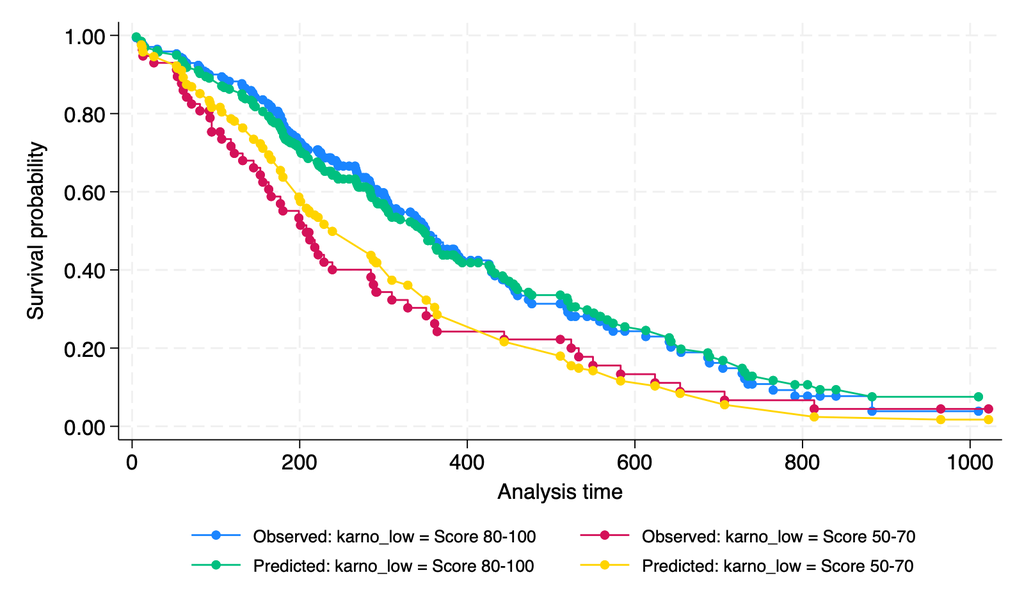

Observed (K-M) vs Cox-predicted

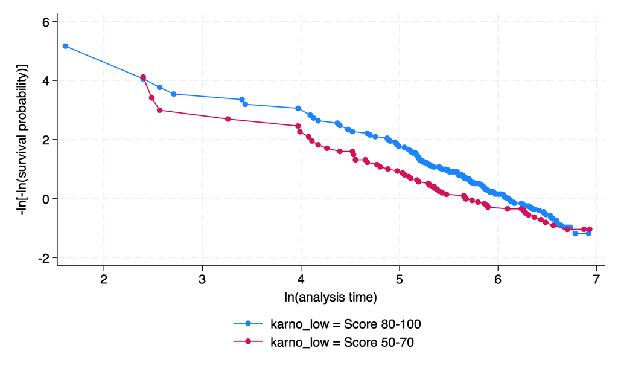

Log-log plot, adjusted for age and sex

- Low-score group: observed survival is below predicted until about day 400 and above it afterwards. The model predicts too few early deaths and too many late deaths.
- The log-log curves are well separated early and converge. Not parallel.

## Task 9, Q2: Schoenfeld residual test

```stata
estat phtest, detail
```

```
Test of proportional-hazards assumption

Time function: Analysis time
--------------------------------------------------------
             |        rho     chi2       df    Prob>chi2
-------------+------------------------------------------
0b.karno_low |          .        .        1           .
 1.karno_low |   -0.18743     6.04        1       0.0140
       age10 |   -0.00551     0.01        1       0.9418
      1b.sex |          .        .        1           .
       2.sex |    0.13060     2.73        1       0.0987
-------------+------------------------------------------
 Global test |                9.25        3       0.0261
--------------------------------------------------------
```

- We reject proportional hazards for `karno_low` (rho = −0.19, p = 0.014)
- All three checks agree: the excess death rate with a low score is concentrated early

## Task 9, Q3: the sex model from task 8

```stata
estat phtest, detail
```

```
Test of proportional-hazards assumption

Time function: Analysis time
--------------------------------------------------------
             |        rho     chi2       df    Prob>chi2
-------------+------------------------------------------
      1b.sex |          .        .        1           .
       2.sex |    0.12767     2.60        1       0.1071
         age |   -0.00899     0.01        1       0.9063
    0b.ecog3 |          .        .        1           .
     1.ecog3 |   -0.00243     0.00        1       0.9751
     2.ecog3 |   -0.09466     1.48        1       0.2238
-------------+------------------------------------------
 Global test |                5.00        4       0.2877
--------------------------------------------------------
```

- We fail to reject proportional hazards (p = 0.11 for sex, global p = 0.29)
- That does not show the hazards are proportional. With 164 deaths the test has limited power, so look at the plots as well.

## Task 9, Q4: what the hazard ratio for `karno_low` measures

- The single hazard ratio of 1.46 is a weighted average of a ratio that changes over time
- It understates the rate ratio in the first months and overstates it later
- The weights depend on when deaths and censoring occur, so longer follow-up of the same patients would give a different number

## Task 10: splitting follow-up time

Commands: `stset` with `id()`, `stsplit`, `stcox`, `test`

One response to non-proportional hazards is to let the hazard ratio differ between an early and a late period. Each patient’s follow-up is split into one record per period.

1. Split follow-up at 180 days. How many records and deaths are in each period?
2. Estimate separate hazard ratios for `karno_low` in days 0 to 180 and after day 180, adjusted for `age10` and sex. Test whether they differ.
3. Karnofsky score may only be a confounder for the effect of sex. Fit a model for sex and `age10` stratified on `karno_low`. Does the hazard ratio for sex change?
4. The 180-day cut point was chosen after looking at the plots in task 9. Why does that matter?

*8 minutes*

## Task 10: hints

**Q1.** `stsplit` needs an id variable. It adds a record for each period a patient survives into and updates `_t0`, `_t` and `_d` (chapter, “Data structure for time to event analysis”).

```stata
generate int id = _n
stset time, failure(stata_status == 1) id(id)
stsplit period, at(180)          // period = 0 or 180
list id _t0 _t _d period karno_low in 1/6
tabulate period _d if !missing(karno_low)
```

**Q2.** Enter both variables in `stcox`, then `test karno_early = karno_late`

```stata
generate byte karno_early = karno_low * (period == 0)
generate byte karno_late  = karno_low * (period == 180)
```

**Q3.** `stcox age10 i.sex if !missing(karno_low), strata(karno_low)`

## Task 10, Q1: the split data

```stata
list id _t0 _t _d period karno_low if inlist(id, 1, 2, 3), noobs clean
tabulate period _d if !missing(karno_low)
```

```
    id   _t0     _t   _d   period      karno_low
     1     0    180    0        0   Score 80-100
     1   180    306    1      180   Score 80-100
     2     0    180    0        0   Score 80-100
     2   180    455    1      180   Score 80-100
     3     0    180    0        0   Score 80-100
     3   180   1010    0      180   Score 80-100

           |  1 if failure; 0 if
Observatio |       censored
n interval |         0          1 |     Total
-----------+----------------------+----------
         0 |       165         62 |       227
       180 |        57        102 |       159
-----------+----------------------+----------
     Total |       222        164 |       386
```

- Each patient who survives past day 180 now has two records. Patient 1: (0, 180] with no death, then (180, 306] ending in death.
- 227 records and 62 deaths in days 0 to 180; 159 records and 102 deaths afterwards. Deaths and person-time are unchanged by the split.

## Task 10, Q2: period-specific hazard ratios

```stata
stcox karno_early karno_late age10 i.sex, nolog noshow
test karno_early = karno_late
```

```
Cox regression with Breslow method for ties

No. of subjects =    227                                Number of obs =    386
No. of failures =    164
Time at risk    = 69,488
                                                        LR chi2(4)    =  23.64
Log likelihood = -732.87642                             Prob > chi2   = 0.0001

------------------------------------------------------------------------------
          _t | Haz. ratio   Std. err.      z    P>|z|     [95% conf. interval]
-------------+----------------------------------------------------------------
 karno_early |    2.33711   .6089398     3.26   0.001     1.402479     3.89459
  karno_late |   1.050758   .2474959     0.21   0.834      .662232    1.667228
       age10 |   1.154691   .1089237     1.52   0.127     .9597775    1.389187
         sex |
     Female  |   .5958459   .0998381    -3.09   0.002     .4290512    .8274823
------------------------------------------------------------------------------


 ( 1)  karno_early - karno_late = 0

           chi2(  1) =    5.26
         Prob > chi2 =    0.0218
```

## Task 10, Q2: interpretation

Low score compared to a score of 80 or more:

- Days 0 to 180: hazard ratio 2.34 (95% CI 1.40 to 3.89). Patients with a low score die at more than twice the rate of the others.
- After day 180: 1.05 (0.66 to 1.67). No difference in rate among patients alive at six months, though the interval is wide.
- The two differ (p = 0.022). The single hazard ratio of 1.46 describes neither period.

## Task 10, Q3: stratified on Karnofsky score

```stata
stcox age10 i.sex if !missing(karno_low), strata(karno_low) nolog
```

```
Stratified Cox regression with Breslow method for ties
Strata variable: karno_low

No. of subjects =    227                                Number of obs =    227
No. of failures =    164
Time at risk    = 69,488
                                                        LR chi2(2)    =  12.73
Log likelihood = -634.83261                             Prob > chi2   = 0.0017

------------------------------------------------------------------------------
          _t | Haz. ratio   Std. err.      z    P>|z|     [95% conf. interval]
-------------+----------------------------------------------------------------
       age10 |   1.170529   .1111666     1.66   0.097     .9717229    1.410009
         sex |
     Female  |   .5979172   .1005332    -3.06   0.002      .430052    .8313066
------------------------------------------------------------------------------
```

Women compared to men: hazard ratio 0.60 (95% CI 0.43 to 0.83). The non-proportional hazards of Karnofsky score do not change the conclusion about sex.

## Task 10, Q4: a cut point chosen from the data

- A cut point chosen because it separates the periods well in these data makes the difference look larger and the p-value smaller than a pre-specified cut point would. Report it as data-driven.
- A step change at day 180 is a summary of a gradual decline
- The late-period estimate describes a selected group: patients with a low score who survived six months

## Take-home points

1. Before modelling, find out when censoring occurs and why
2. Rescale and center continuous covariates so that the hazard ratio and the baseline hazard describe real patients
3. A strong predictor is a confounder only if it is also associated with the exposure
4. Check proportional hazards with plots and the test together. A large sample allows the test to reject small departures. For small samples the test has low power.
5. Responses to non-proportional hazards: stratify on a covariate that is not of interest; split follow-up time for one that is
6. The subgroup with the largest hazard ratio is not necessarily the one with the largest difference in absolute risk; that also depends on baseline risk
7. With a competing event, 1 − KM overstates the probability. Use the cumulative incidence for probabilities and cause-specific hazard ratios for rates.
8. An adjusted hazard ratio from observational data is not a treatment effect